# GEO 200CN Lab 6

Kenneth Larrieu

May 6, 2019

# Local Regression

## California Precipitation

```r
library(rspatial)
# load county polygons and spatial precipitation data
counties <- sp_data('counties')
p <- sp_data('precipitation')
head(p)
```

```
##      ID                 NAME   LAT    LONG ALT  JAN FEB MAR APR MAY JUN
## 1 ID741         DEATH VALLEY 36.47 -116.87 -59  7.4 9.5 7.5 3.4 1.7 1.0
## 2 ID743  THERMAL/FAA AIRPORT 33.63 -116.17 -34  9.2 6.9 7.9 1.8 1.6 0.4
## 3 ID744          BRAWLEY 2SW 32.96 -115.55 -31 11.3 8.3 7.6 2.0 0.8 0.1
## 4 ID753 IMPERIAL/FAA AIRPORT 32.83 -115.57 -18 10.6 7.0 6.1 2.5 0.2 0.0
## 5 ID754               NILAND 33.28 -115.51 -18  9.0 8.0 9.0 3.0 0.0 1.0
## 6 ID758        EL CENTRO/NAF 32.82 -115.67 -13  9.8 1.6 3.7 3.0 0.4 0.0
##   JUL  AUG SEP OCT NOV DEC
## 1 3.7  2.8 4.3 2.2 4.7 3.9
## 2 1.9  3.4 5.3 2.0 6.3 5.5
## 3 1.9  9.2 6.5 5.0 4.8 9.7
## 4 2.4  2.6 8.3 5.4 7.7 7.3
## 5 8.0  9.0 7.0 8.0 7.0 9.0
## 6 3.0 10.8 0.2 0.0 3.3 1.4
```

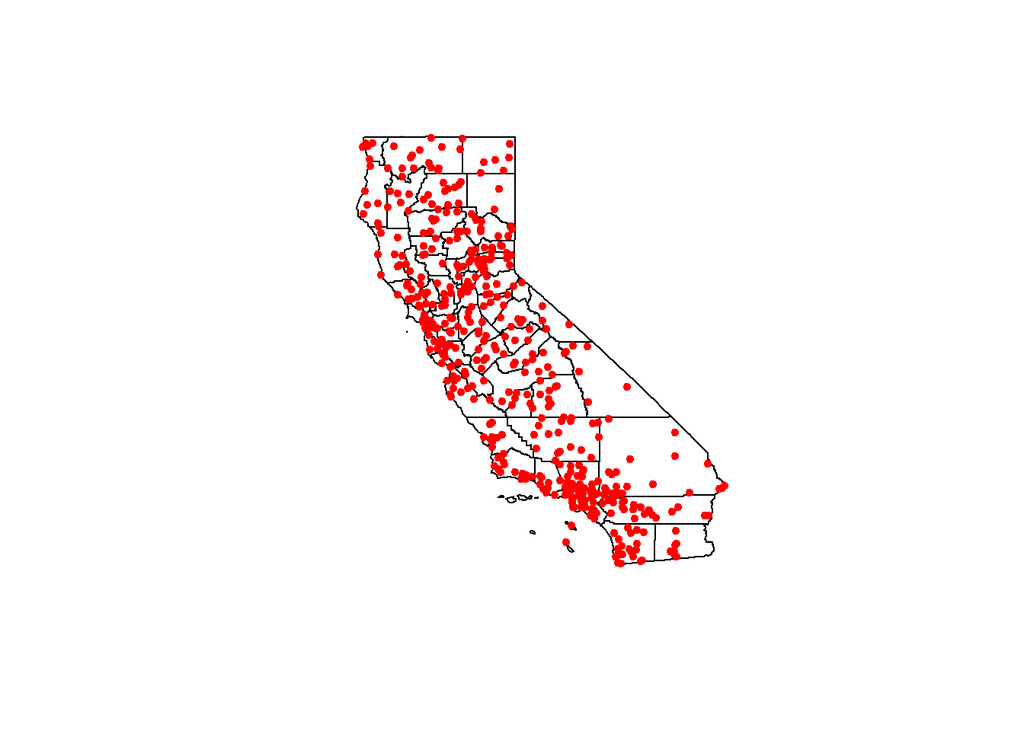

```r
plot(counties)
points(p[,c('LONG', 'LAT')], col='red', pch=20)
```

```r
# sum average precip over all months to get average annual precip
p$pan <- rowSums(p[,6:17])
```

```r
# global regression on precip as function of altitude
m <- lm(pan ~ ALT, data=p)
m
```

```
##
## Call:
## lm(formula = pan ~ ALT, data = p)
##
## Coefficients:
## (Intercept)          ALT
##      523.60         0.17
```

```r
# give both objects same projection
alb <- CRS("+proj=aea +lat_1=34 +lat_2=40.5 +lat_0=0 +lon_0=-120 +x_0=0 +y_0=-4000000 +ellps=GRS80 +datum=NAD83 +units=m +no_defs")
sp <- p
coordinates(sp) = ~ LONG + LAT
crs(sp) <- "+proj=longlat +datum=NAD83"
spt <- spTransform(sp, alb)
ctst <- spTransform(counties, alb)
```

```r
library( spgwr )
# local regression: get optimal bandwidth
bw <- gwr.sel(pan ~ ALT, data=spt)
```

```
## Bandwidth: 526221.1 CV score: 64886883
## Bandwidth: 850593.6 CV score: 74209073
## Bandwidth: 325747.9 CV score: 54001118
## Bandwidth: 201848.6 CV score: 44611213
## Bandwidth: 125274.7 CV score: 35746320
## Bandwidth: 77949.39 CV score: 29181737
## Bandwidth: 48700.74 CV score: 22737197
## Bandwidth: 30624.09 CV score: 17457161
## Bandwidth: 19452.1 CV score: 15163436
## Bandwidth: 12547.43 CV score: 19452191
## Bandwidth: 22792.75 CV score: 15512988
## Bandwidth: 17052.67 CV score: 15709960
## Bandwidth: 20218.99 CV score: 15167438
## Bandwidth: 19767.99 CV score: 15156913
## Bandwidth: 19790.05 CV score: 15156906
## Bandwidth: 19781.39 CV score: 15156902
## Bandwidth: 19781.48 CV score: 15156902
## Bandwidth: 19781.47 CV score: 15156902
## Bandwidth: 19781.47 CV score: 15156902
## Bandwidth: 19781.47 CV score: 15156902
## Bandwidth: 19781.47 CV score: 15156902
```

```r
bw
```

```
## [1] 19781.47
```

```r
# create regular set of points to estimate precip for
r <- raster(ctst, res=10000)
r <- rasterize(ctst, r)
newpts <- rasterToPoints(r)
```

```r
# perform local regression using optimal bandwidth as before, and fit the new points
g <- gwr(pan ~ ALT, data=spt, bandwidth=bw, fit.points=newpts[, 1:2])
g
```

```
## Call:
## gwr(formula = pan ~ ALT, data = spt, bandwidth = bw, fit.points = newpts[,
##     1:2])
## Kernel function: gwr.Gauss
## Fixed bandwidth: 19781.47
## Fit points: 4087
## Summary of GWR coefficient estimates at fit points:
##                    Min.    1st Qu.     Median    3rd Qu.      Max.
## X.Intercept. -702.40121   79.54254  330.48807  735.42718 3468.8702
## ALT            -3.91270    0.03058    0.20461    0.41542    4.6133
```

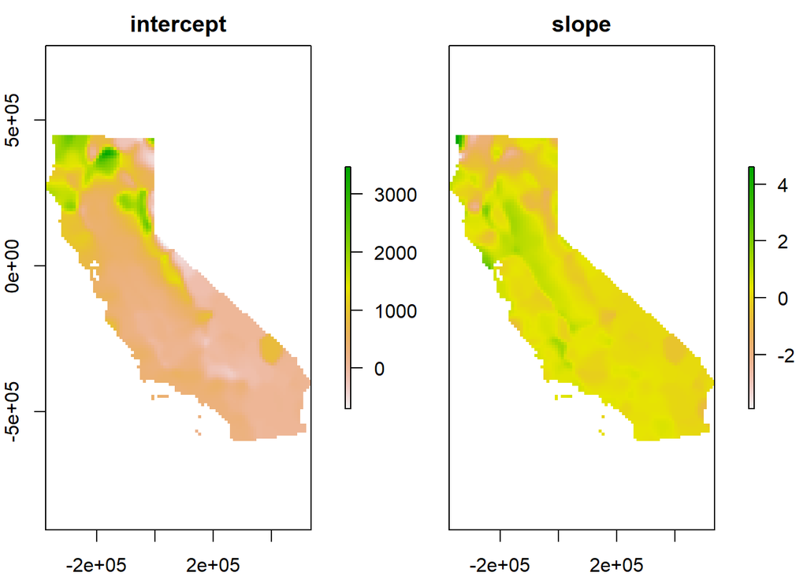

```r
# link spatially distributed regression coefficients back to raster and plot it
slope <- r
intercept <- r
slope[!is.na(slope)] <- g$SDF$ALT
intercept[!is.na(intercept)] <- g$SDF$'(Intercept)'
s <- stack(intercept, slope)
names(s) <- c('intercept', 'slope')
plot(s)
```

## House Price Data

```r
# load data
houses <- sp_data("houses1990.csv")
dim(houses)
```

```
## [1] 20640     9
```

```r
head(houses)
```

```
##   houseValue income houseAge rooms bedrooms population households latitude
## 1     452600 8.3252       41   880      129        322        126    37.88
## 2     358500 8.3014       21  7099     1106       2401       1138    37.86
## 3     352100 7.2574       52  1467      190        496        177    37.85
## 4     341300 5.6431       52  1274      235        558        219    37.85
## 5     342200 3.8462       52  1627      280        565        259    37.85
## 6     269700 4.0368       52   919      213        413        193    37.85
##   longitude
## 1   -122.23
## 2   -122.22
## 3   -122.24
## 4   -122.25
## 5   -122.25
## 6   -122.25
```

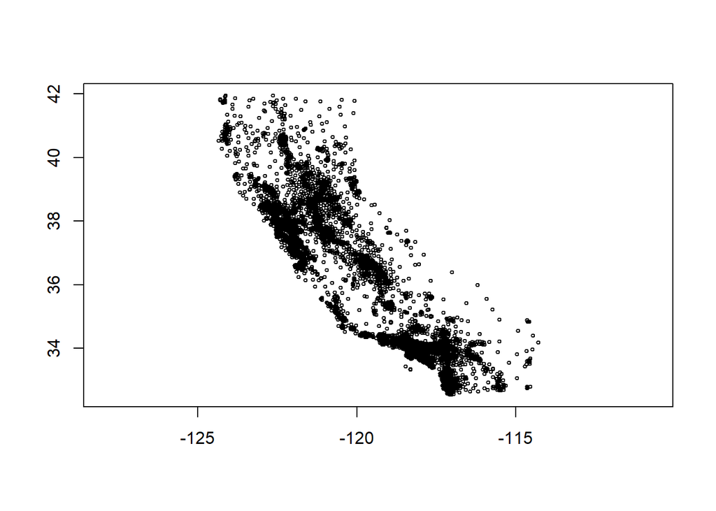

```r
library(sp)
coordinates(houses) <- ~longitude+latitude
# plot coordinates of census blockgroups
plot(houses, cex=0.5, pch=1, axes=TRUE)
```

```r
library(raster)
# give houses same crs as counties
crs(houses) <- crs(counties)
# match house data points to corresponding county
cnty <- over(houses, counties)
head(cnty)
```

```
##   STATE COUNTY    NAME LSAD LSAD_TRANS
## 1    06    001 Alameda   06     County
## 2    06    001 Alameda   06     County
## 3    06    001 Alameda   06     County
## 4    06    001 Alameda   06     County
## 5    06    001 Alameda   06     County
## 6    06    001 Alameda   06     County
```

```r
# combine county data and house data into single dataframe
hd <- cbind(data.frame(houses), cnty)
# calculate total population by county
totpop <- tapply(hd$population, hd$NAME, sum)
totpop
```

```
##         Alameda          Alpine          Amador           Butte
##         1241779            1113           30039          182120
##       Calaveras          Colusa    Contra Costa       Del Norte
##           31998           16275          799017           16045
##       El Dorado          Fresno           Glenn        Humboldt
##          128624          662261           24798          116418
##        Imperial            Inyo            Kern           Kings
##          108633           18281          528995           91842
##            Lake          Lassen     Los Angeles          Madera
##           50631           27214         8721937           88089
##           Marin        Mariposa       Mendocino          Merced
##          204241           14302           75061          176457
##           Modoc            Mono        Monterey            Napa
##            9678            9956          342314          108030
##          Nevada          Orange          Placer          Plumas
##           78510         2340204          170761           19739
##       Riverside      Sacramento      San Benito  San Bernardino
##         1162787         1038540           36697         1409740
##       San Diego   San Francisco     San Joaquin San Luis Obispo
##         2425153          683068          477184          203764
##       San Mateo   Santa Barbara     Santa Clara      Santa Cruz
##          614816          335177         1486054          216732
##          Shasta          Sierra        Siskiyou          Solano
##          147036            3318           43531          337429
##          Sonoma      Stanislaus          Sutter          Tehama
##          385296          370821           63689           49625
##         Trinity          Tulare        Tuolumne         Ventura
##           13063          309073           48456          649935
##            Yolo            Yuba
##          138799           58954
```

```r
# total income
hd$suminc <- hd$income * hd$households
# now use aggregate (similar to tapply)
csum <- aggregate(hd[, c('suminc', 'households')], list(hd$NAME), sum)
# divide total income by number of households
csum$income <- 10000 * csum$suminc / csum$households
# sort
csum <- csum[order(csum$income), ]
head(csum)
```

```
##     Group.1    suminc households   income
## 53  Trinity 11198.985       5156 21720.30
## 58     Yuba 43739.708      19882 21999.65
## 25    Modoc  8260.597       3711 22259.76
## 47 Siskiyou 38769.952      17302 22407.79
## 17     Lake 47612.899      20805 22885.32
## 11    Glenn 20497.683       8821 23237.37
```

### Global Regression:

```r
hd$roomhead <- hd$rooms / hd$population
hd$bedroomhead <- hd$bedrooms / hd$population
hd$hhsize <- hd$population / hd$households

# OLS
m <- glm( houseValue ~ income + houseAge + roomhead + bedroomhead + population, data=hd)
summary(m)
```

```
##
## Call:
## glm(formula = houseValue ~ income + houseAge + roomhead + bedroomhead +
##     population, data = hd)
##
## Deviance Residuals:
##      Min        1Q    Median        3Q       Max
## -1226134    -48590    -12944     34425    461948
##
## Coefficients:
##               Estimate Std. Error t value Pr(>|t|)
## (Intercept) -6.508e+04  2.533e+03 -25.686  < 2e-16 ***
## income       5.179e+04  3.833e+02 135.092  < 2e-16 ***
## houseAge     1.832e+03  4.575e+01  40.039  < 2e-16 ***
## roomhead    -4.720e+04  1.489e+03 -31.688  < 2e-16 ***
## bedroomhead  2.648e+05  6.820e+03  38.823  < 2e-16 ***
## population   3.947e+00  5.081e-01   7.769 8.27e-15 ***
## ---
## Signif. codes:  0 '***' 0.001 '**' 0.01 '*' 0.05 '.' 0.1 ' ' 1
##
## (Dispersion parameter for gaussian family taken to be 6022427437)
##
##     Null deviance: 2.7483e+14  on 20639  degrees of freedom
## Residual deviance: 1.2427e+14  on 20634  degrees of freedom
## AIC: 523369
##
## Number of Fisher Scoring iterations: 2
```

### GWR by county:

```r
# remove records outside county boundaries
hd2 <- hd[!is.na(hd$NAME), ]
```

```r
# function to get regression coefficients
regfun <- function(x)  {
  dat <- hd2[hd2$NAME == x, ]
  m <- glm(houseValue~income+houseAge+roomhead+bedroomhead+population, data=dat)
  coefficients(m)
}
```

```r
# run regression for each county
countynames <- unique(hd2$NAME)
res <- sapply(countynames, regfun)
```

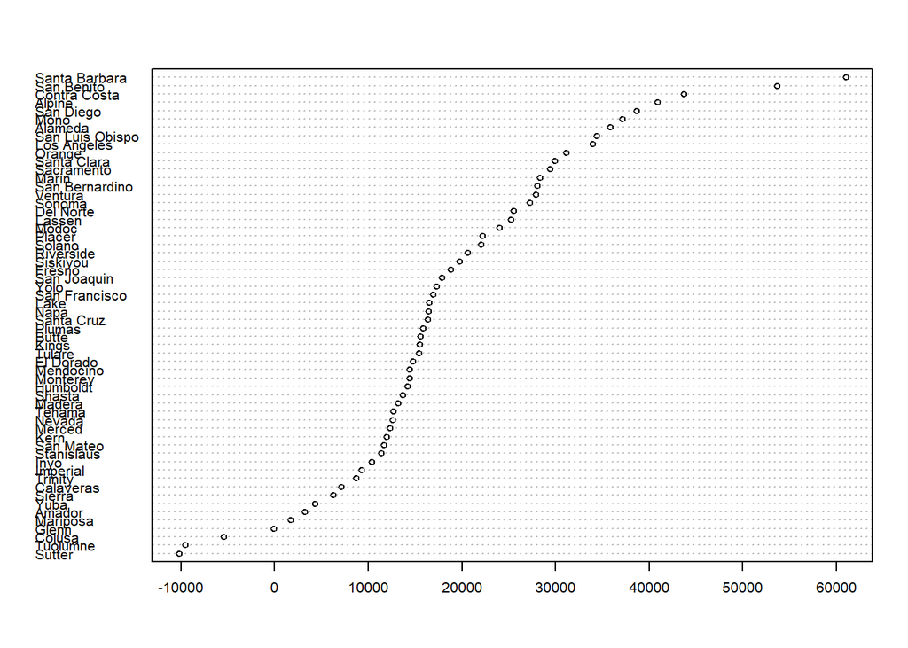

```r
dotchart(sort(res['income', ]), cex=0.65)
```

```r
resdf <- data.frame(NAME=colnames(res), t(res))
head(resdf)
```

```
##                      NAME X.Intercept.    income  houseAge   roomhead
## Alameda           Alameda    -62373.62 35842.330  591.1001 24147.3182
## Contra Costa Contra Costa    -61759.84 43668.442  465.8897  -356.6085
## Alpine             Alpine    -77605.93 40850.588 5595.4113         NA
## Amador             Amador    120480.71  3234.519 -771.5857 37997.0069
## Butte               Butte     50935.36 15577.745 -380.5824  9078.9315
## Calaveras       Calaveras     91364.72  7126.668 -929.4065 16843.3456
##              bedroomhead population
## Alameda        129814.33  8.0570859
## Contra Costa   150662.89  0.8869663
## Alpine                NA         NA
## Amador        -194176.65  0.9971630
## Butte          -32272.68  5.7707597
## Calaveras      -78749.86  8.8865713
```

```r
dcounties <- aggregate(counties, vars='NAME')
```

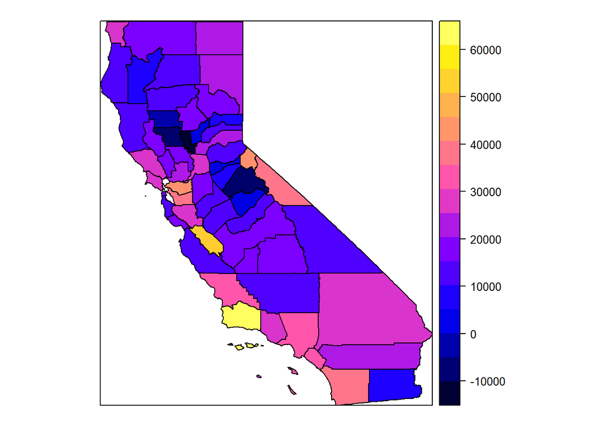

```r
cnres <- merge(dcounties, resdf, by='NAME')
spplot(cnres, 'income')
```

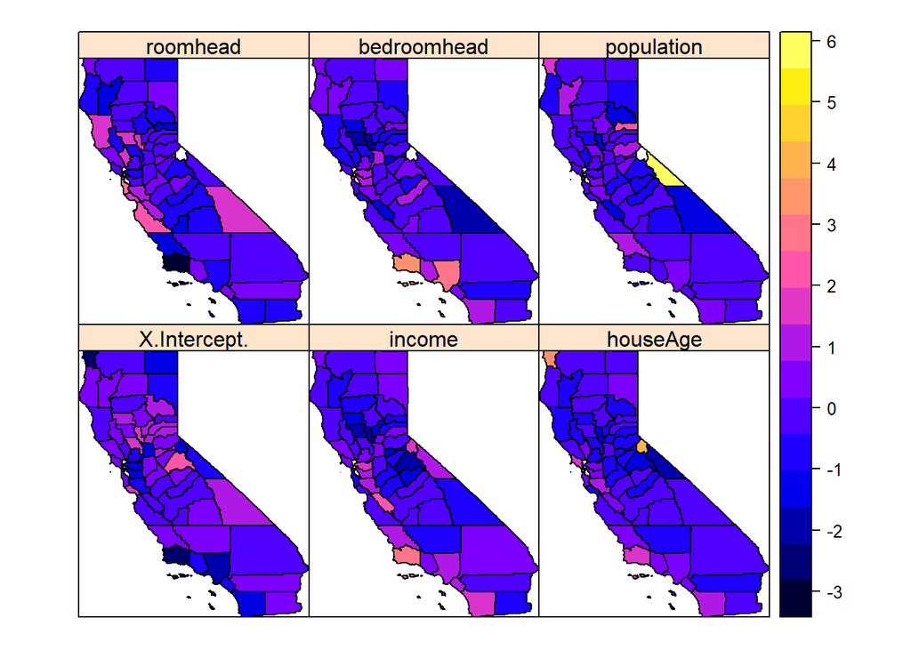

```r
# a copy of the data
cnres2 <- cnres
# scale all variables, except the first one (county name)
# assigning values to a "@data" slot is risky, but (I think) OK here
cnres2@data = data.frame(scale(data.frame(cnres)[, -1]))
spplot(cnres2)
```

```r
library(spdep)
```

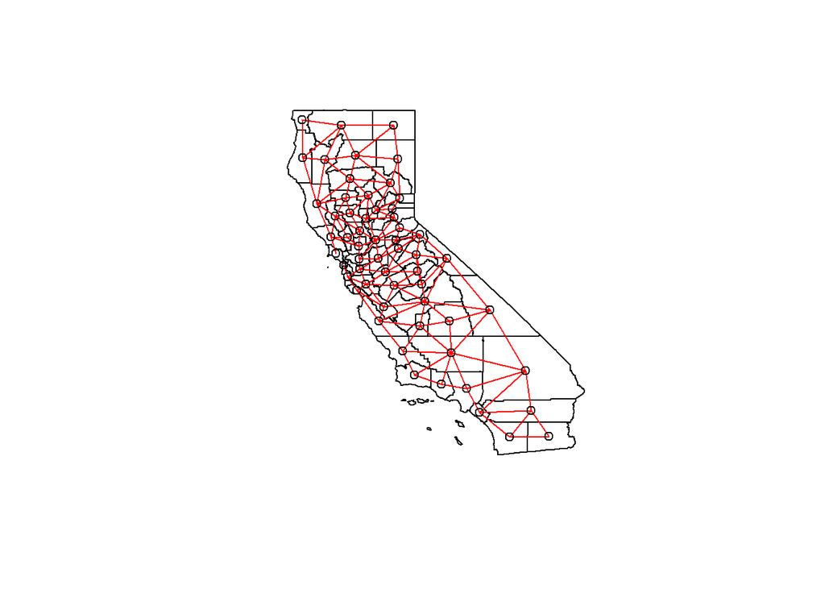

```r
## Loading required package: Matrix
nb <- poly2nb(cnres)
plot(cnres)
plot(nb, coordinates(cnres), add=T, col='red')
```

```r
lw <- nb2listw(nb)
moran.test(cnres$income, lw)
```

```
##
##  Moran I test under randomisation
##
## data:  cnres$income
## weights: lw
##
## Moran I statistic standard deviate = 2.2473, p-value = 0.01231
## alternative hypothesis: greater
## sample estimates:
## Moran I statistic       Expectation          Variance
##       0.173419996      -0.017543860       0.007220867
```

### Alternate approach: GWR by grid cells

```r
TA <- CRS("+proj=aea +lat_1=34 +lat_2=40.5 +lat_0=0 +lon_0=-120 +x_0=0 +y_0=-4000000
              +datum=NAD83 +units=m +no_defs +ellps=GRS80 +towgs84=0,0,0")
countiesTA <- spTransform(counties, TA)
```

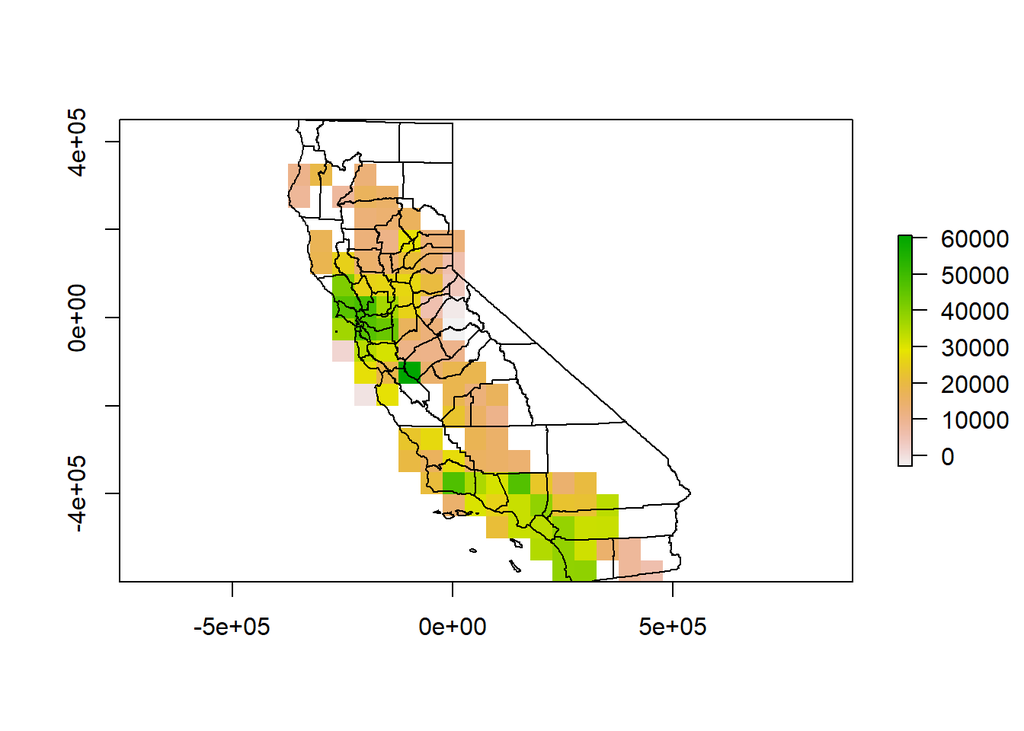

```r
library(raster)
r <- raster(countiesTA)
res(r) <- 50000
# get coordinates of each raster cell
xy <- xyFromCell(r, 1:ncell(r))
# convert houses to TA crs
housesTA <- spTransform(houses, TA)
crds <- coordinates(housesTA)

# define regression function which returns local coefficients
regfun2 <- function(d)  {
 m <- glm(houseValue~income+houseAge+roomhead+bedroomhead+population, data=d)
 coefficients(m)
}
# get all local regression coefficients
res <- list()
for (i in 1:nrow(xy)) {
    d <- sqrt((xy[i,1]-crds[,1])^2 + (xy[i,2]-crds[,2])^2)
    j <- which(d < 50000)
    if (length(j) > 49) {
        d <- hd[j,]
        res[[i]] <- regfun2(d)
    } else {
        res[[i]] <- NA
    }
}

inc <- sapply(res, function(x) x['income'])

rinc <- setValues(r, inc)
plot(rinc)
plot(countiesTA, add=T)
```

```r
Moran(rinc)
```

```
## [1] 0.3271564
```

**Question 1**: Can you comment on weaknesses (and perhaps strengths) of the approaches I have shown?

- GWR by county: The size and geometry of each county is highly variable, e.g. SF county compared to San Bernadino county. Thus, the county polygons used to define a local neighborhood for GWR are somewhat arbitrary. Whatever determinines the spatial variation in the effect of input variables on house price may not be dependent upon county boundaries, but instead proximity to other areas.
- GWR by grid cells: The grid cell size does not allow us to predict values for the entire state.

In both cases, the GWR may be susceptible to multicollinearity issues due to correlation between input variables for some of the local models.

### spgwr package

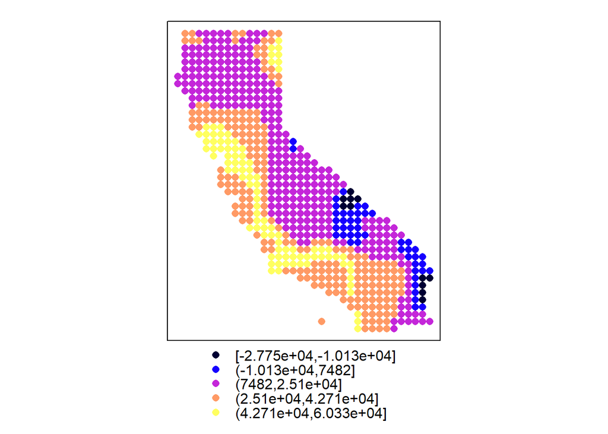

```r
library(spgwr)
# Create raster with correct extent and 25km resolution
r <- raster(countiesTA)
res(r) <- 25000
# get cells in CA
ca <- rasterize(countiesTA, r)
fitpoints <- rasterToPoints(ca)
fitpoints <- fitpoints[,-3]
# specify the model
gwr.model <- gwr(formula=houseValue~income+houseAge+rooms+bedrooms+population, data=housesTA, bandwidth=40000, fit.points=fitpoints)

sp <- gwr.model$SDF

spplot(sp, 'income')
```

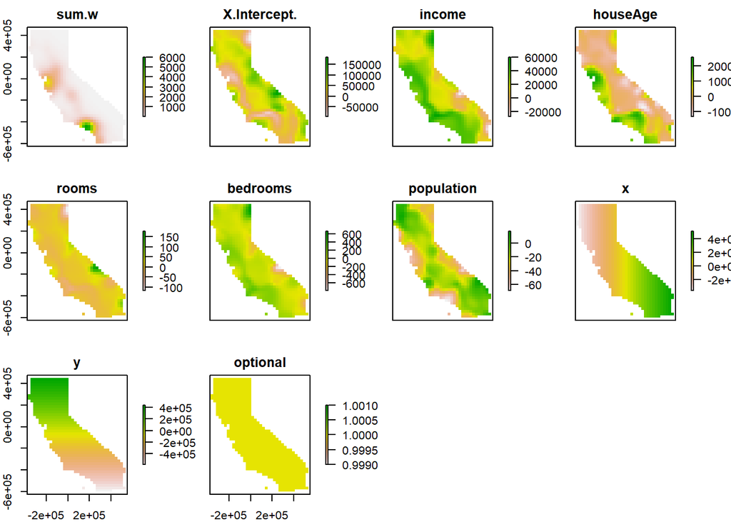

```r
cells <- cellFromXY(r, fitpoints)
dd <- as.matrix(data.frame(sp))
b <- brick(r, values=FALSE, nl=ncol(dd))
b[cells] <- dd
names(b) <- colnames(dd)
plot(b)
```

**Question 2**: Briefly comment on the results and the differences (if any) with the two home-brew examples.

This method has a much finer resolution due to the lack of aggregation on a county/grid scale, but rather by bandwidth, so it seems to represent the local variation better.

# Interpolation

```r
library(rspatial)
# load precipitation dataframe
d <- sp_data('precipitation')
head(d)
```

```
##      ID                 NAME   LAT    LONG ALT  JAN FEB MAR APR MAY JUN
## 1 ID741         DEATH VALLEY 36.47 -116.87 -59  7.4 9.5 7.5 3.4 1.7 1.0
## 2 ID743  THERMAL/FAA AIRPORT 33.63 -116.17 -34  9.2 6.9 7.9 1.8 1.6 0.4
## 3 ID744          BRAWLEY 2SW 32.96 -115.55 -31 11.3 8.3 7.6 2.0 0.8 0.1
## 4 ID753 IMPERIAL/FAA AIRPORT 32.83 -115.57 -18 10.6 7.0 6.1 2.5 0.2 0.0
## 5 ID754               NILAND 33.28 -115.51 -18  9.0 8.0 9.0 3.0 0.0 1.0
## 6 ID758        EL CENTRO/NAF 32.82 -115.67 -13  9.8 1.6 3.7 3.0 0.4 0.0
##   JUL  AUG SEP OCT NOV DEC
## 1 3.7  2.8 4.3 2.2 4.7 3.9
## 2 1.9  3.4 5.3 2.0 6.3 5.5
## 3 1.9  9.2 6.5 5.0 4.8 9.7
## 4 2.4  2.6 8.3 5.4 7.7 7.3
## 5 8.0  9.0 7.0 8.0 7.0 9.0
## 6 3.0 10.8 0.2 0.0 3.3 1.4
```

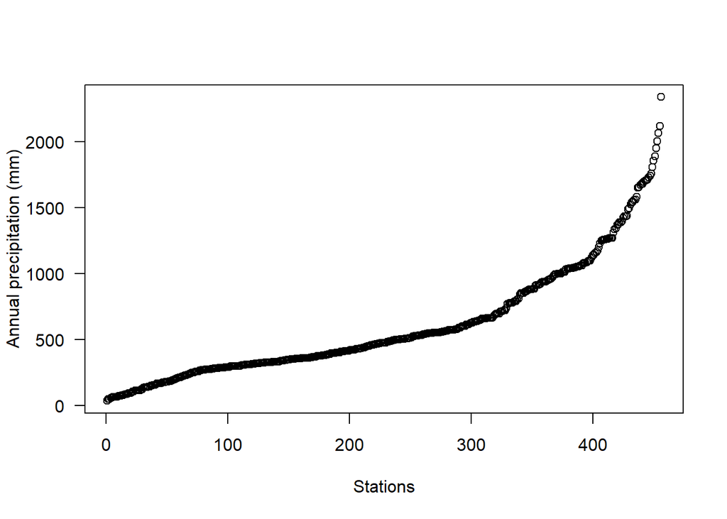

```r
# calculate annual precip
d$prec <- rowSums(d[, c(6:17)])
# plot distribution
plot(sort(d$prec), ylab='Annual precipitation (mm)', las=1, xlab='Stations')
```

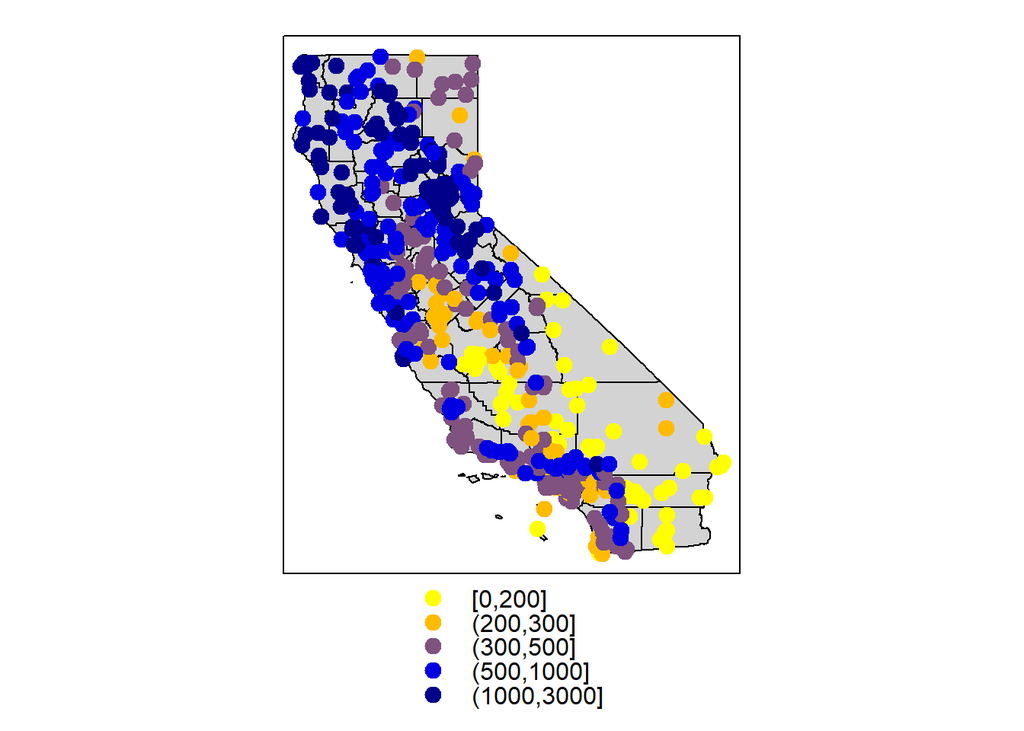

```r
library(sp)
# make data into spatial object
dsp <- SpatialPoints(d[,4:3], proj4string=CRS("+proj=longlat +datum=NAD83"))
dsp <- SpatialPointsDataFrame(dsp, d)
CA <- sp_data("counties")
# define groups for mapping
cuts <- c(0,200,300,500,1000,3000)
# set up a palette of interpolated colors
blues <- colorRampPalette(c('yellow', 'orange', 'blue', 'dark blue'))
pols <- list("sp.polygons", CA, fill = "lightgray")
spplot(dsp, 'prec', cuts=cuts, col.regions=blues(5), sp.layout=pols, pch=20, cex=2)
```

```r
# convert data to Teale-Albers
TA <- CRS("+proj=aea +lat_1=34 +lat_2=40.5 +lat_0=0 +lon_0=-120 +x_0=0 +y_0=-4000000 +datum=NAD83 +units=m +ellps=GRS80 +towgs84=0,0,0")
library(rgdal)
dta <- spTransform(dsp, TA)
cata <- spTransform(CA, TA)
```

We can get the RMSE for the null model (the data mean) as a baseline comparison against other models:

```r
# make a function which calculates RMSE
RMSE <- function(observed, predicted) {
  sqrt(mean((predicted - observed)^2, na.rm=TRUE))
}

# calculate RMSE for null model
null <- RMSE(mean(dsp$prec), dsp$prec)
null
```

```
## [1] 435.3217
```

### Thiessen polygons

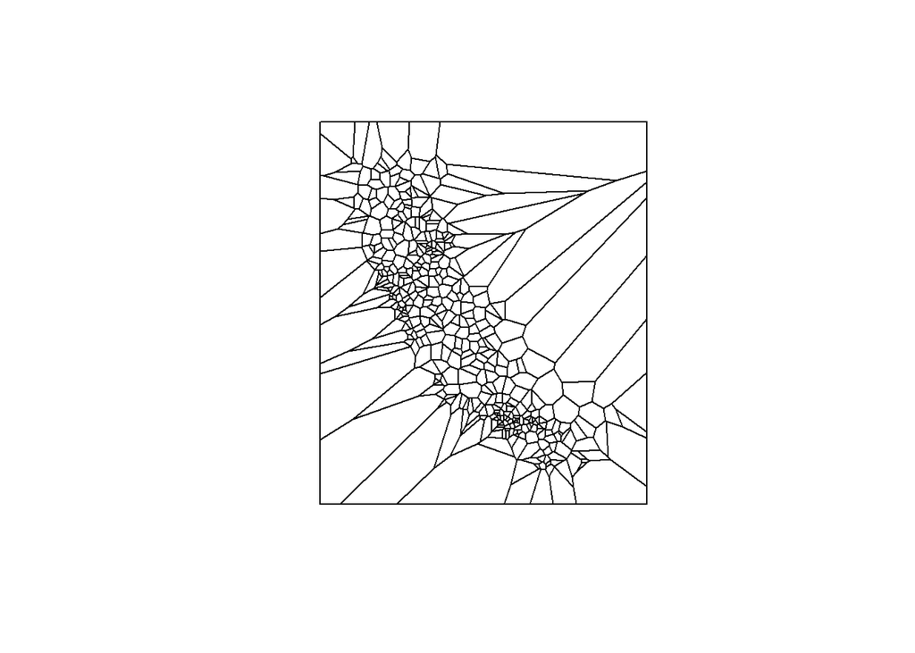

```r
library(dismo)
v <- voronoi(dta)
plot(v)
```

Interesect with CA boundary so it doesn’t look so weird, and color by precip of nearest gague

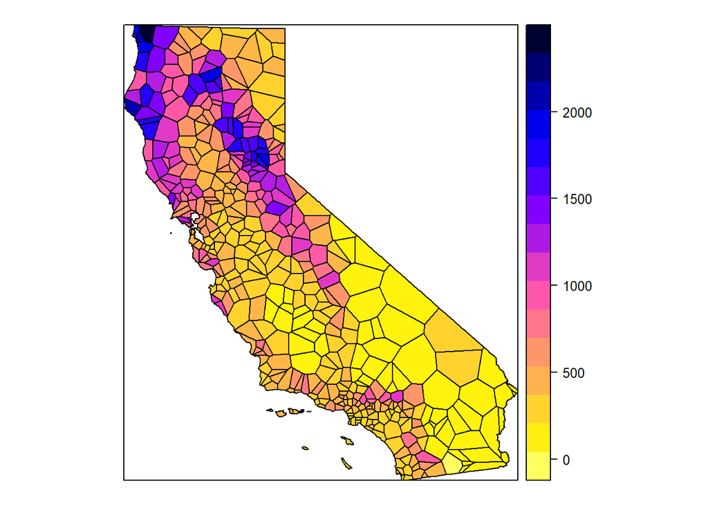

```r
ca <- aggregate(cata)
vca <- intersect(v, ca)
spplot(vca, 'prec', col.regions=rev(get_col_regions()))
```

Converting these polygons to a raster:

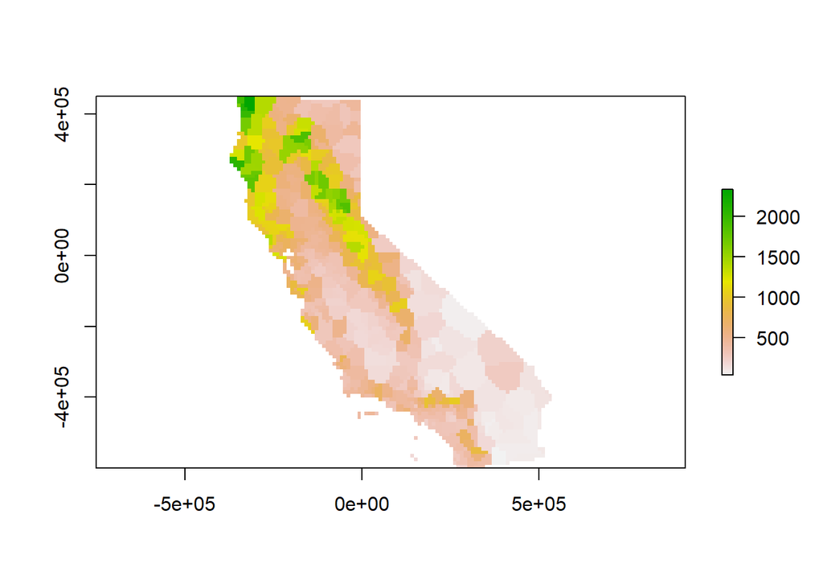

```r
r <- raster(cata, res=10000)
vr <- rasterize(vca, r, 'prec')
plot(vr)
```

Now evaluate with 5-fold cross-validation:

```r
set.seed(5132015)
kf <- kfold(nrow(dta))
rmse <- rep(NA, 5)
for (k in 1:5) {
  test <- dta[kf == k, ]
  train <- dta[kf != k, ]
  v <- voronoi(train)
  p <- extract(v, test)
  rmse[k] <- RMSE(test$prec, p$prec)
}

rmse
```

```
## [1] 199.0686 187.8069 166.9153 191.0938 238.9696
```

```r
mean(rmse)
```

```
## [1] 196.7708
```

```r
1 - (mean(rmse) / null)
```

```
## [1] 0.5479875
```

**Question 1:** Describe what each step in the code chunk above does.

**Question 2:** How does the proximity-polygon approach compare to the NULL model?

From the last output above we see that the Thiessen polygon model achieves ~55% reduction in RMSE compared to the null model.

**Question 3:** You would not typically use proximty polygons for rainfall data. For what kind of data would you use them?

Proximity polygons are best suited for categorical variables, e.g. land cover type.

## Nearest neighbor interpolation

Setting inverse distance power to 0 and `nmax=5` uses the 5 nearest neighbors weighted equally:

```r
library(gstat)
gs <- gstat(formula=prec~1, locations=dta, nmax=5, set=list(idp = 0))
nn <- interpolate(r, gs)
```

```
## [inverse distance weighted interpolation]
```

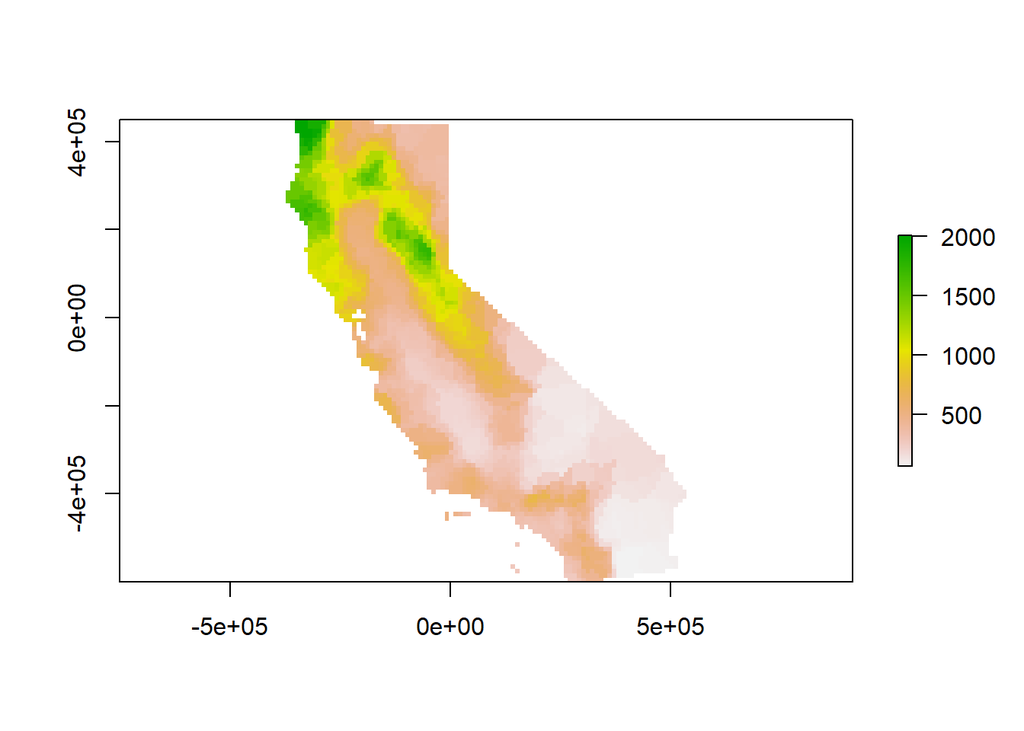

```r
## [inverse distance weighted interpolation]
nnmsk <- mask(nn, vr)
plot(nnmsk)
```

Cross-validate the results:

```r
rmsenn <- rep(NA, 5)
for (k in 1:5) {
  test <- dta[kf == k, ]
  train <- dta[kf != k, ]
  gscv <- gstat(formula=prec~1, locations=train, nmax=5, set=list(idp = 0))
  p <- predict(gscv, test)$var1.pred
  rmsenn[k] <- RMSE(test$prec, p)
}
```

```
## [inverse distance weighted interpolation]
## [inverse distance weighted interpolation]
## [inverse distance weighted interpolation]
## [inverse distance weighted interpolation]
## [inverse distance weighted interpolation]
```

```r
rmsenn
```

```
## [1] 200.6222 190.8336 180.3833 169.9658 237.9067
```

```r
mean(rmsenn)
```

```
## [1] 195.9423
```

```r
1 - (mean(rmsenn) / null)
```

```
## [1] 0.5498908
```

Now using inverse distance weighted (IDW) interpolation:

```r
gs <- gstat(formula=prec~1, locations=dta)
idw <- interpolate(r, gs)
```

```
## [inverse distance weighted interpolation]
```

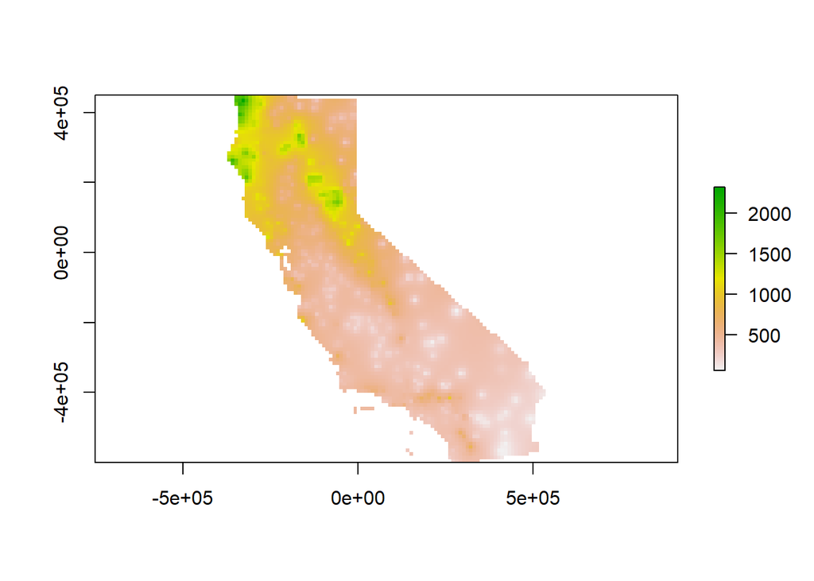

```r
## [inverse distance weighted interpolation]
idwr <- mask(idw, vr)
plot(idwr)
```

**Question 4:** IDW generated rasters tend to have a noticeable artefact. What is that?

IDW generated rasters tend to have a “spotted” look, due to the isotropic weighting of each gague.

Cross validating the IDW model:

```r
rmse <- rep(NA, 5)
for (k in 1:5) {
  test <- dta[kf == k, ]
  train <- dta[kf != k, ]
  gs <- gstat(formula=prec~1, locations=train)
  p <- predict(gs, test)
  rmse[k] <- RMSE(test$prec, p$var1.pred)
}
```

```
## [inverse distance weighted interpolation]
## [inverse distance weighted interpolation]
## [inverse distance weighted interpolation]
## [inverse distance weighted interpolation]
## [inverse distance weighted interpolation]
```

```r
rmse
```

```
## [1] 215.3319 211.9383 190.0231 211.8308 230.1893
```

```r
mean(rmse)
```

```
## [1] 211.8627
```

```r
1 - (mean(rmse) / null)
```

```
## [1] 0.5133192
```

**Question 5:** Inspect the arguments used for and make a map of the IDW model below. What other name could you give to this method (IDW with these parameters)? Why?

```r
gs2 <- gstat(formula=prec~1, locations=dta, nmax=1, set=list(idp=1))
```

This code chunk is actually just nearest neighbor/proximity polygon interpolation, since it is only using one neighbor (`nmax=1`), and the inverse distance power weights are normalized to unity. Therefore, it assigns each point the value of the nearest gague.

## CA Air Pollution Data

```r
x <- sp_data("airqual")
x$OZDLYAV <- x$OZDLYAV * 1000

library(sp)
coordinates(x) <- ~LONGITUDE + LATITUDE
proj4string(x) <- CRS('+proj=longlat +datum=NAD83')
TA <- CRS("+proj=aea +lat_1=34 +lat_2=40.5 +lat_0=0 +lon_0=-120 +x_0=0 +y_0=-4000000 +datum=NAD83 +units=km +ellps=GRS80")
library(rgdal)
aq <- spTransform(x, TA)

cageo <- sp_data('counties.rds')
ca <- spTransform(cageo, TA)
r <- raster(ca)
res(r) <- 10  # 10 km if your CRS's units are in km
g <- as(r, 'SpatialGrid')
```

Plotting an empirical variogram:

```r
library(gstat)
gs <- gstat(formula=OZDLYAV~1, locations=aq)
v <- variogram(gs, width=20)
head(v)
```

```
##     np      dist    gamma dir.hor dir.ver   id
## 1 1010  11.35040 34.80579       0       0 var1
## 2 1806  30.63737 47.52591       0       0 var1
## 3 2355  50.58656 67.26548       0       0 var1
## 4 2619  70.10411 80.92707       0       0 var1
## 5 2967  90.13917 88.93653       0       0 var1
## 6 3437 110.42302 84.13589       0       0 var1
```

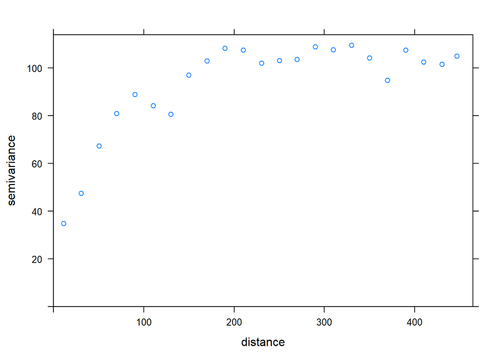

```r
plot(v)
```

Fitting and plotting a model variogram:

```r
fve <- fit.variogram(v, vgm(85, "Exp", 75, 20))
fve
```

```
##   model    psill    range
## 1   Nug 21.96600  0.00000
## 2   Exp 85.52957 72.31404
```

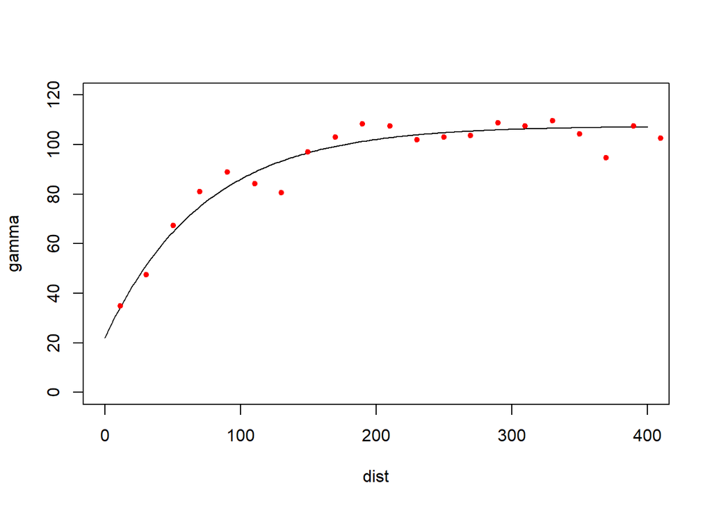

```r
plot(variogramLine(fve, 400), type='l', ylim=c(0,120))
points(v[,2:3], pch=20, col='red')
```

Try a different type (spherical in stead of exponential)

```r
fvs <- fit.variogram(v, vgm(85, "Sph", 75, 20))
fvs
```

```
##   model    psill    range
## 1   Nug 25.57019   0.0000
## 2   Sph 72.65881 135.7744
```

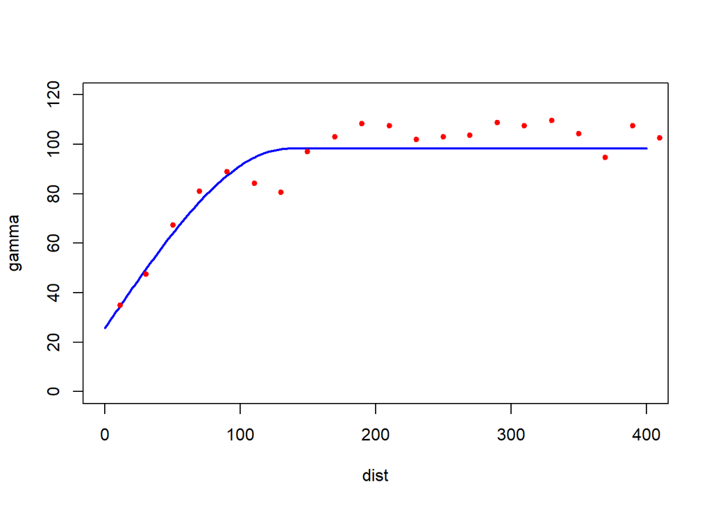

```r
plot(variogramLine(fvs, 400), type='l', ylim=c(0,120) ,col='blue', lwd=2)
points(v[,2:3], pch=20, col='red')
```

## Ordinary Kriging

```r
k <- gstat(formula=OZDLYAV~1, locations=aq, model=fve)
# predicted values
kp <- predict(k, g)
```

```
## [using ordinary kriging]
```

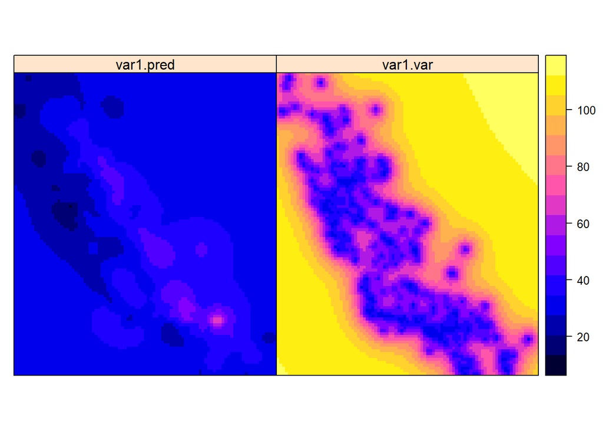

```r
## [using ordinary kriging]
spplot(kp)
```

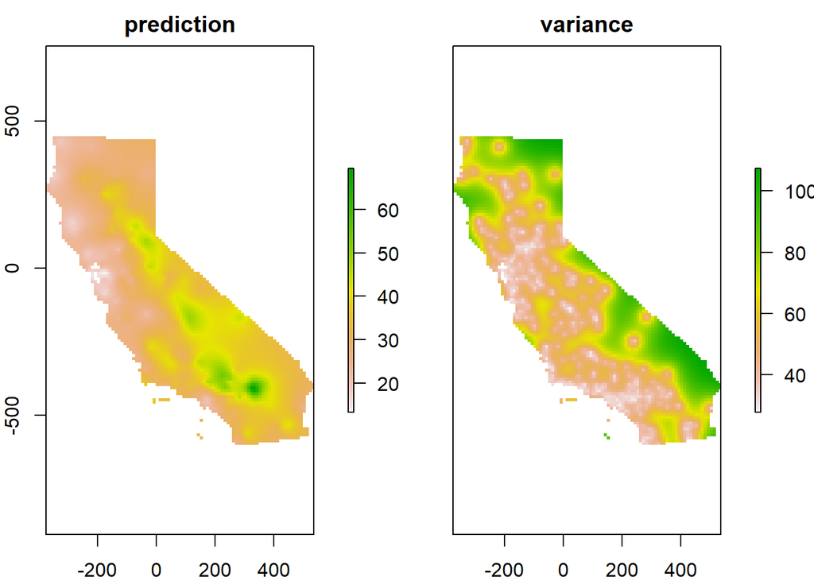

```r
# variance
ok <- brick(kp)
ok <- mask(ok, ca)
names(ok) <- c('prediction', 'variance')
plot(ok)
```

### Compare with other methods

Using IDW again:

```r
library(gstat)
idm <- gstat(formula=OZDLYAV~1, locations=aq)
idp <- interpolate(r, idm)
```

```
## [inverse distance weighted interpolation]
```

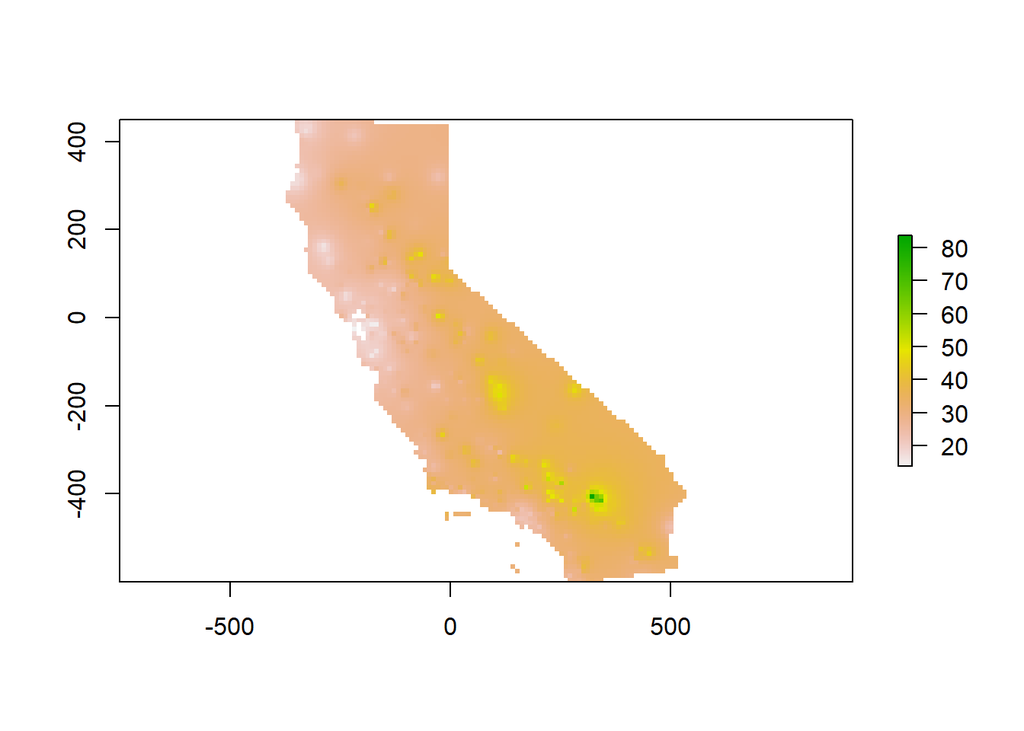

```r
## [inverse distance weighted interpolation]
idp <- mask(idp, ca)
plot(idp)
```

```r
RMSE <- function(observed, predicted) {
  sqrt(mean((predicted - observed)^2, na.rm=TRUE))
}
f1 <- function(x, test, train) {
  nmx <- x[1]
  idp <- x[2]
  if (nmx < 1) return(Inf)
  if (idp < .001) return(Inf)
  m <- gstat(formula=OZDLYAV~1, locations=train, nmax=nmx, set=list(idp=idp))
  p <- predict(m, newdata=test, debug.level=0)$var1.pred
  RMSE(test$OZDLYAV, p)
}
set.seed(20150518)
i <- sample(nrow(aq), 0.2 * nrow(aq))
tst <- aq[i,]
trn <- aq[-i,]
opt <- optim(c(8, .5), f1, test=tst, train=trn)
opt
```

```
## $par
## [1] 9.1569933 0.4521968
##
## $value
## [1] 7.28701
##
## $counts
## function gradient
##       41       NA
##
## $convergence
## [1] 0
##
## $message
## NULL
```

```r
m <- gstat(formula=OZDLYAV~1, locations=aq, nmax=opt$par[1], set=list(idp=opt$par[2]))
idw <- interpolate(r, m)
```

```
## [inverse distance weighted interpolation]
```

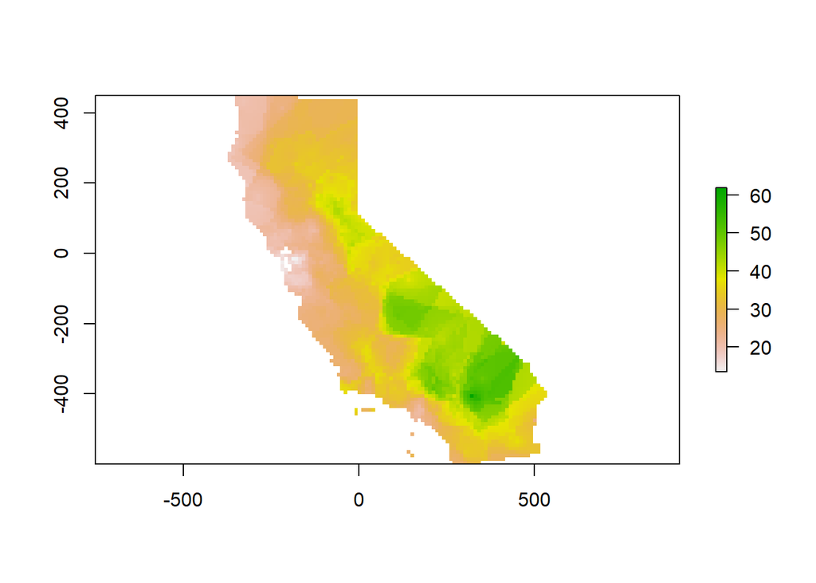

```r
## [inverse distance weighted interpolation]
idw <- mask(idw, ca)
plot(idw)
```

Thin plate spline model:

```r
library(fields)
```

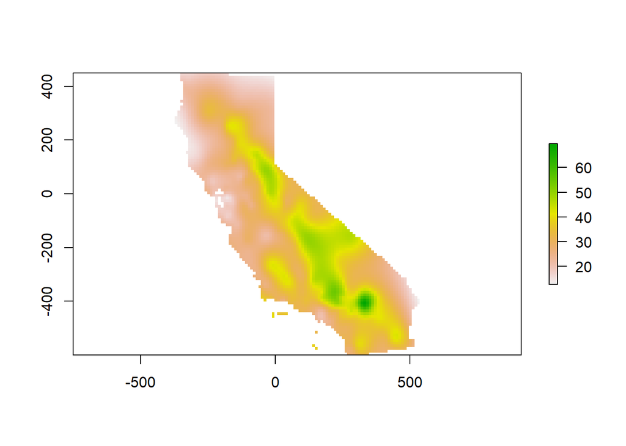

```r
m <- Tps(coordinates(aq), aq$OZDLYAV)
tps <- interpolate(r, m)
tps <- mask(tps, idw)
plot(tps)
```

Cross-validate the three methods (IDW, OK, TPS) and add ensemble model:

```r
library(dismo)
nfolds <- 5
k <- kfold(aq, nfolds)
ensrmse <- tpsrmse <- krigrmse <- idwrmse <- rep(NA, 5)
for (i in 1:nfolds) {
  test <- aq[k!=i,]
  train <- aq[k==i,]
  m <- gstat(formula=OZDLYAV~1, locations=train, nmax=opt$par[1], set=list(idp=opt$par[2]))
  p1 <- predict(m, newdata=test, debug.level=0)$var1.pred
  idwrmse[i] <-  RMSE(test$OZDLYAV, p1)
  m <- gstat(formula=OZDLYAV~1, locations=train, model=fve)
  p2 <- predict(m, newdata=test, debug.level=0)$var1.pred
  krigrmse[i] <-  RMSE(test$OZDLYAV, p2)
  m <- Tps(coordinates(train), train$OZDLYAV)
  p3 <- predict(m, coordinates(test))
  tpsrmse[i] <-  RMSE(test$OZDLYAV, p3)
  w <- c(idwrmse[i], krigrmse[i], tpsrmse[i])
  weights <- w / sum(w)
  ensemble <- p1 * weights[1] + p2 * weights[2] + p3 * weights[3]
  ensrmse[i] <-  RMSE(test$OZDLYAV, ensemble)
}
rmi <- mean(idwrmse)
rmk <- mean(krigrmse)
rmt <- mean(tpsrmse)
rms <- c(rmi, rmt, rmk)
rms
```

```
## [1] 7.925989 8.816963 7.588549
```

```r
## [1] 8.041305 8.307235 7.930799
rme <- mean(ensrmse)
rme
```

```
## [1] 7.718896
```

```r
## [1] 7.858051
```

**Question 6:** Which method performed best?

Making the weighted ensemble and plotting it along with the other three methods:

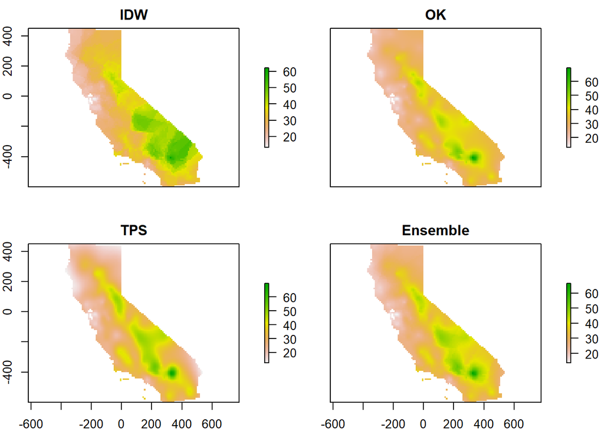

```r
weights <- ( rms / sum(rms) )
s <- stack(idw, ok[[1]], tps)
ensemble <- sum(s * weights)

s <- stack(idw, ok[[1]], tps, ensemble)
names(s) <- c('IDW', 'OK', 'TPS', 'Ensemble')
plot(s)
```

**Question 7:** Show where the largest difference exist between IDW and OK.

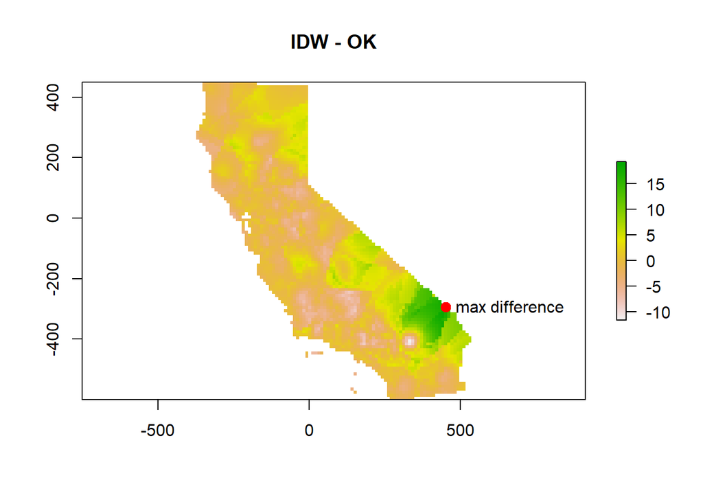

```r
# difference between IDW and OK
diff = s$IDW - s$OK
# get location of maximum difference
i = which.max(diff)
pos = xyFromCell(diff,i)
pos = SpatialPoints(pos)
# plot it
plot(diff, main="IDW - OK")
plot(pos, add=T, pch=20, col='red', cex=2)
text(pos, labels='max difference', pos=4)
```

**Question 8:** Show where the difference between IDW and OK is within the 95% confidence limit of the OK prediction.

[figure not shown]

```r
# calculate OK confidence interval
# z score for 95% confidence interval
z = 1.96
# standard deviation of the values
sigma = sqrt(ok$variance)
# number of observations
n = length(aq)
# lower and upper confidence interval bounds
ci_lower = ok$prediction - z*sigma/sqrt(n)
ci_upper = ok$prediction + z*sigma/sqrt(n)
# check if diff is within confidence interval
in_ci = idw
in_ci[in_ci < ci_lower] = NA
in_ci[in_ci > ci_upper] = NA
# plot it
plot(in_ci, main='IDW predictions outside Kriging CI')
plot(aggregate(ca), add=T)
```

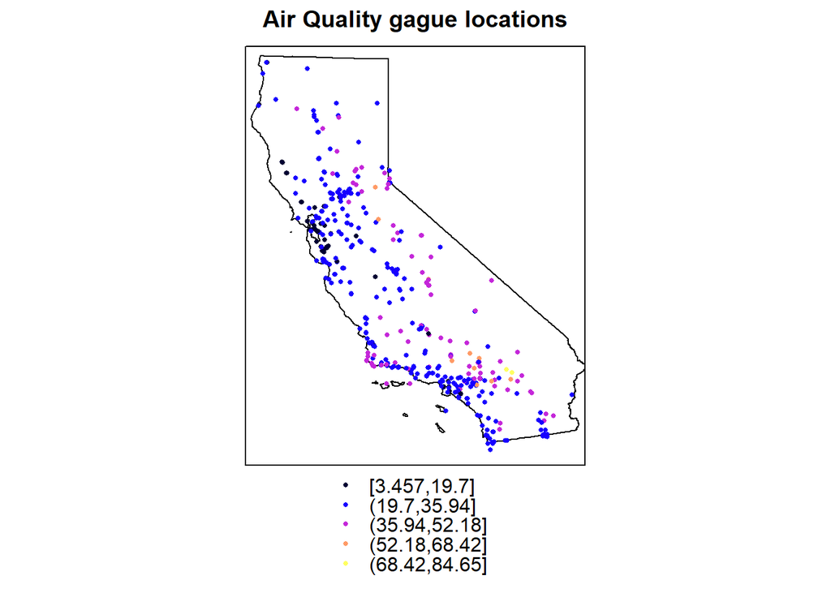

```r
spplot(aq, 'OZDLYAV', main='Air Quality gague locations', cex=0.5, sp.layout = aggregate(ca), add=T)
```

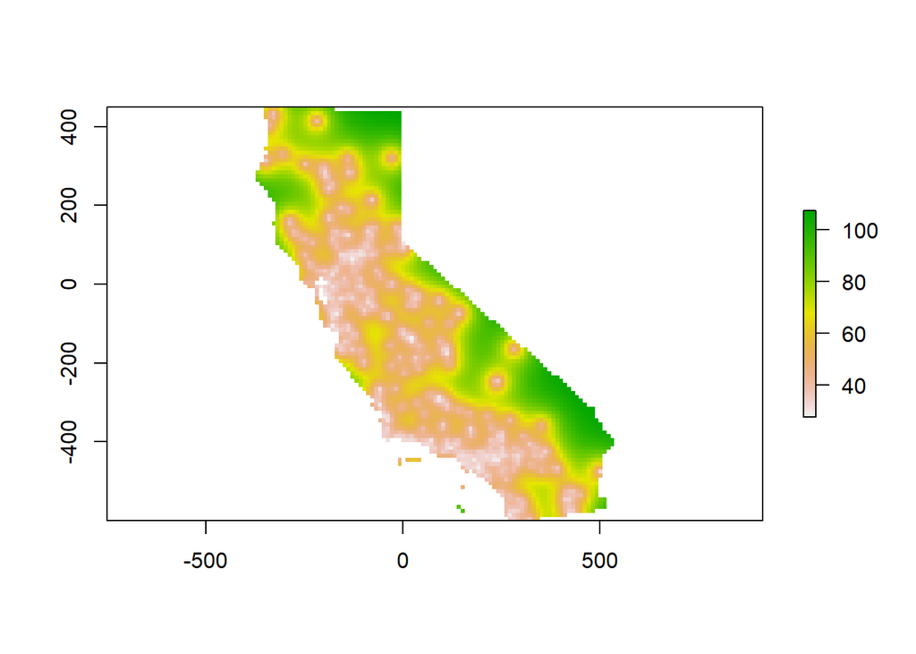

```r
plot(ok$variance)
```

**Question 9:** Can you describe the pattern we are seeing, and speculate about what is causing it?